# IODS course project

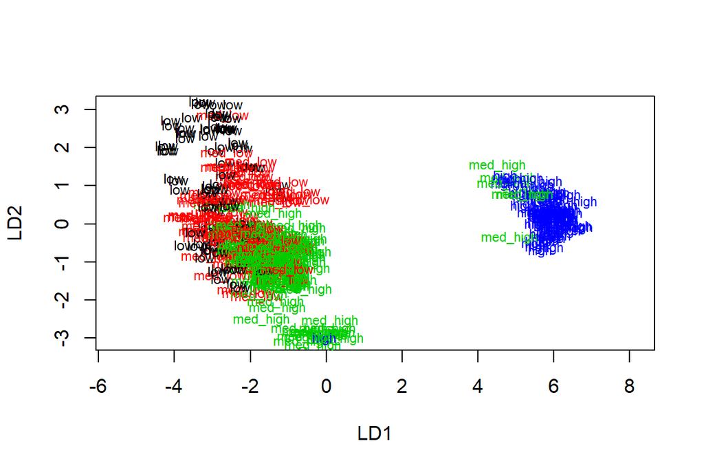

```r
#The values are now between -10 and 10, and all the mean values are 0, as per the scaling function.
boston_scaled<- as.data.frame(boston_scaled)
bins<-quantile(boston_scaled$crim)
bb<-c("low", "med_low", "med_high", "high")
crime <- cut(boston_scaled$crim, breaks = bins, include.lowest = TRUE, label=bb)
#table(crime)
boston_scaled <- dplyr::select(boston_scaled, -crim)
boston_scaled <- data.frame(boston_scaled, crime)
n<-nrow(boston_scaled)
ind<-sample(n, size=n*0.8)
train<-boston_scaled[ind,]
test<-boston_scaled[-ind,]
correct_classes <- test$crime
test <- dplyr::select(test, -crime)
lda.fit <- lda(crime~., data = train)
#lda.fit
classes <- as.numeric(train$crime)
lda.arrows <- function(x, myscale = 1, arrow_heads = 0.1, color = "red", tex = 0.75, choices = c(1,2)){
  heads <- coef(x)
  arrows(x0 = 0, y0 = 0,
         x1 = myscale * heads[,choices[1]],
         y1 = myscale * heads[,choices[2]], col=color, length = arrow_heads)
  text(myscale * heads[,choices], labels = row.names(heads),
       cex = tex, col=color, pos=3)
}
plot(lda.fit, dimen = 2, col=classes, pch=classes)
```

```r
#For some reason the data is reversed on the x-axis compared to the datacamp plot, I went through the whole code and couldn't find why
#lda.arrows(lda.fit, myscale = 10) // commented to reduce knitting time
lda.pred <- predict(lda.fit, newdata = test)
table(correct = correct_classes, predicted = lda.pred$class)
```

```
##           predicted
## correct    low med_low med_high high
##   low       15      14        0    0
##   med_low    4      15        5    0
##   med_high   0       5       11    0
##   high       0       0        0   33
```

*As we can see, the predict function was quite good at predicting crime rates overall, particularly high crime rates. This would imply that high crime rates exhibit a certain tell that the LDA uses to predict with high accuracy. The low, med_low and med_high categories seem to be quite easily separated from the high-category.*

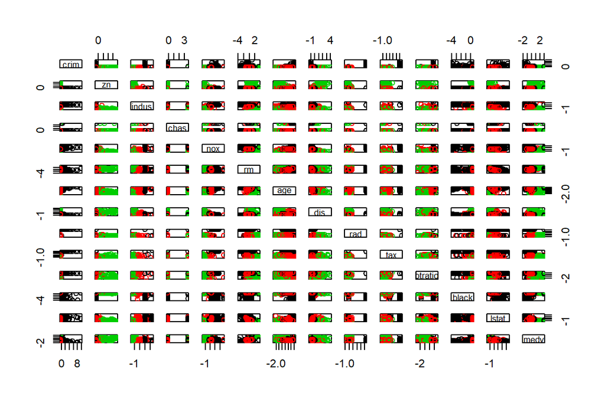

```r
data("Boston")
bos<-scale(Boston)
#Euclidean and Manhattan distance
dist_eu<-dist(bos)
dist_man<-dist(bos, method="manhattan")
km<-kmeans(bos, centers=3)
pairs(bos, col=km$cluster)
```

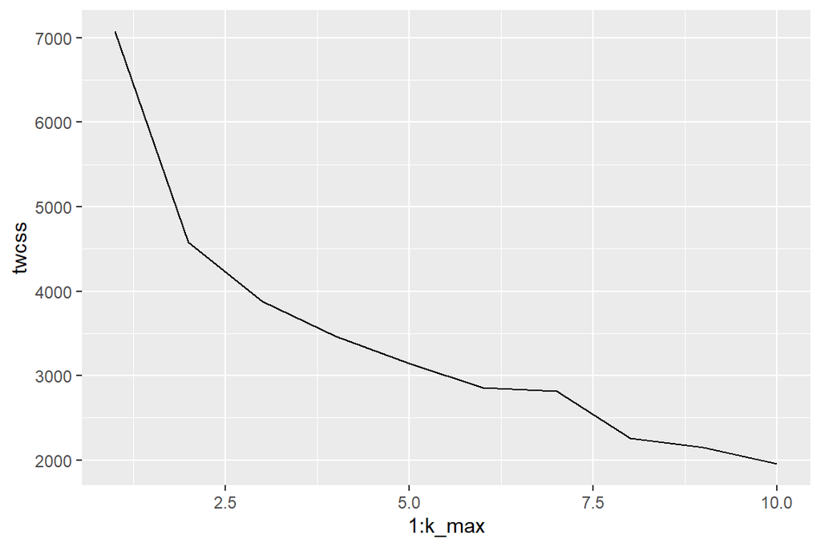

```r
set.seed(123)
k_max<-10
twcss<-sapply(1:k_max, function(k){kmeans(bos, k)$tot.withinss})
qplot(x = 1:k_max, y = twcss, geom = 'line')
```

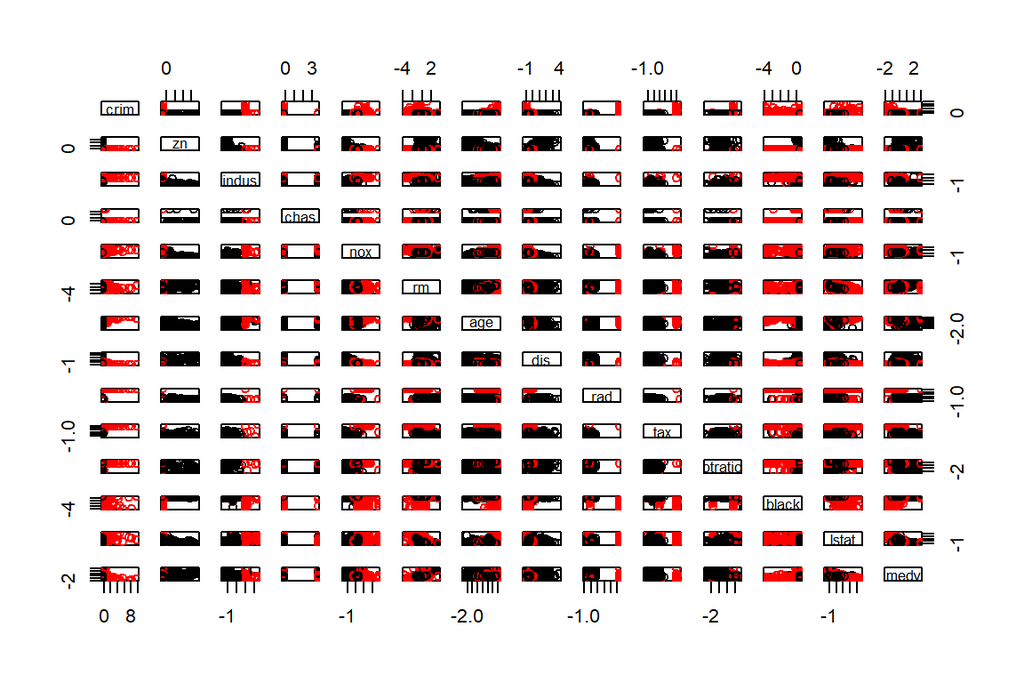

```r
km <-kmeans(bos, centers = 2)
pairs(bos, col = km$cluster)
```

*2 clusters seems to be what brings most change, making it the optimal number. This graph has grouped the data in the scaled bos-table into 2 clusters, and then maps that data according to the stated categories. It appears to have divided dwellings largely based on whether they’re in an industrial area (with a high nitrogen oxide concentration) or not, and so we can use the graph to figure out what things correspond or don’t correspond with living in an industrial area, like for example that people living in those areas generally have a lower tax rate. Unfortunately I can’t select specific columns to look at more closely for some reason, so that’s about all I can gather from the tiny images.* ***

# Chapter 5

```r
library(tidyr); library(dplyr); library(ggplot2); library(corrplot); library(GGally);
human<-read.csv(file="Human.csv", header=T, sep=",")
dim(human)
```

```
## [1] 155   9
```

```r
rownames(human)<-human$X
human<-dplyr::select(human, -X)
```

*For some reason it gives me the names as a column again, so they have to be removed again for ggpairs to work.*

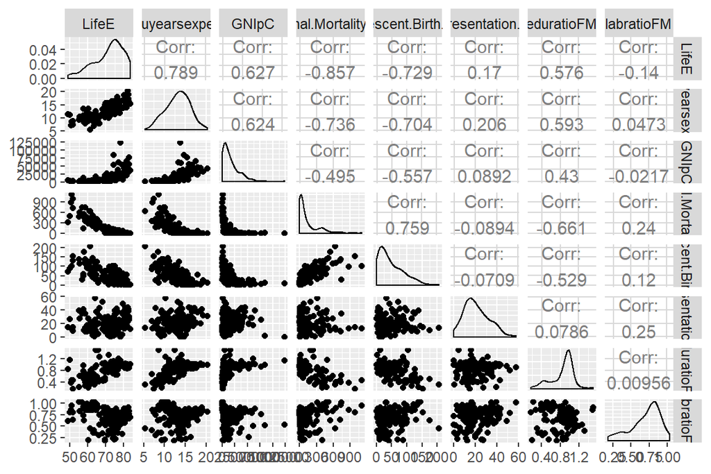

```r
ggpairs(human)
```

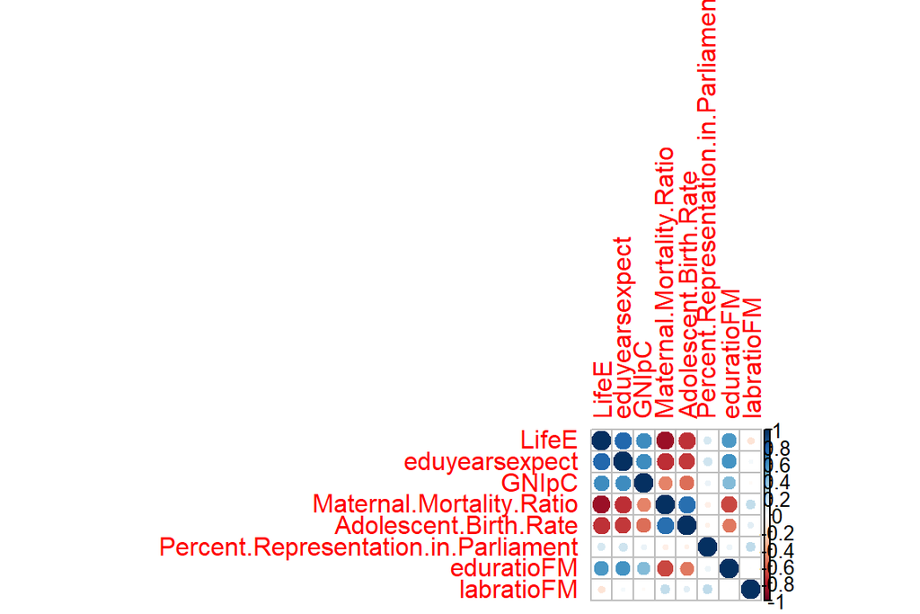

```r
cor(human)%>%corrplot()
```

*The data represents basic human development metrics such as life expectancy and average education, and shows relationships between these variables. The plots show us, among other things, that countries with many adolescent births also have significantly higher maternal mortality rates and lower life expectancies, and that countries where women receive more similar levels of education to men generally have better education as a whole and don’t have as many adolescent births. The better educated countries with higher life expectancies also have higher GNIs per capita, which can probably be expected.*

```r
pca_human<-prcomp(human)
pca_human
```

```
## Standard deviations (1, .., p=8):
## [1] 1.854416e+04 1.855219e+02 2.518701e+01 1.145441e+01 3.766241e+00
## [6] 1.565912e+00 1.912052e-01 1.591112e-01
##
## Rotation (n x k) = (8 x 8):
##                                                PC1           PC2
## LifeE                                -2.815823e-04 -0.0283150248
## eduyearsexpect                       -9.562910e-05 -0.0075529759
## GNIpC                                -9.999832e-01  0.0057723054
## Maternal.Mortality.Ratio              5.655734e-03  0.9916320120
## Adolescent.Birth.Rate                 1.233961e-03  0.1255502723
## Percent.Representation.in.Parliament -5.526460e-05 -0.0032317269
## eduratioFM                           -5.607472e-06 -0.0006713951
## labratioFM                            2.331945e-07  0.0002819357
##                                                PC3           PC4
## LifeE                                -1.294971e-02  6.752684e-02
## eduyearsexpect                       -1.427664e-02  3.313505e-02
## GNIpC                                 5.156742e-04 -4.932889e-05
## Maternal.Mortality.Ratio             -1.260302e-01  6.100534e-03
## Adolescent.Birth.Rate                 9.918113e-01 -5.301595e-03
## Percent.Representation.in.Parliament  7.398331e-03  9.971232e-01
## eduratioFM                            3.412027e-05  2.736326e-04
## labratioFM                           -5.302884e-04  4.692578e-03
##                                                PC5           PC6
## LifeE                                 0.9865644425  1.453515e-01
## eduyearsexpect                        0.1431180282 -9.882477e-01
## GNIpC                                -0.0001135863  2.711698e-05
## Maternal.Mortality.Ratio              0.0266373214 -1.695203e-03
## Adolescent.Birth.Rate                 0.0188618600 -1.273198e-02
## Percent.Representation.in.Parliament -0.0716401914  2.309896e-02
## eduratioFM                           -0.0022935252 -2.180183e-02
## labratioFM                            0.0022190154 -3.264423e-02
##                                                PC7           PC8
## LifeE                                -5.380452e-03  2.281723e-03
## eduyearsexpect                        3.826887e-02  7.776451e-03
## GNIpC                                 8.075191e-07 -1.176762e-06
## Maternal.Mortality.Ratio             -1.355518e-04  8.371934e-04
## Adolescent.Birth.Rate                 8.641234e-05 -1.707885e-04
## Percent.Representation.in.Parliament  2.642548e-03  2.680113e-03
## eduratioFM                           -6.998623e-01  7.139410e-01
## labratioFM                           -7.132267e-01 -7.001533e-01
```

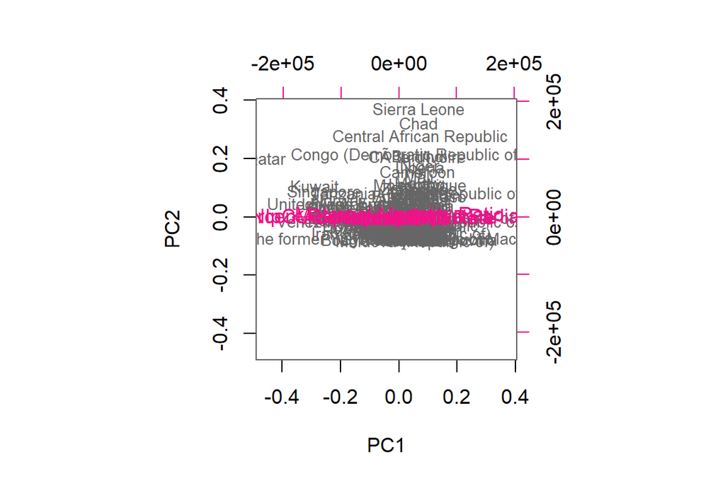

```r
biplot(pca_human, choices=1:2, cex=c(0.8, 1), col=c("grey40", "deeppink2"))
```

```r
s <- summary(pca_human)
pca_pr <- round(100*s$importance[2, ], digits = 1)
pca_pr
```

```
## PC1 PC2 PC3 PC4 PC5 PC6 PC7 PC8
## 100   0   0   0   0   0   0   0
```

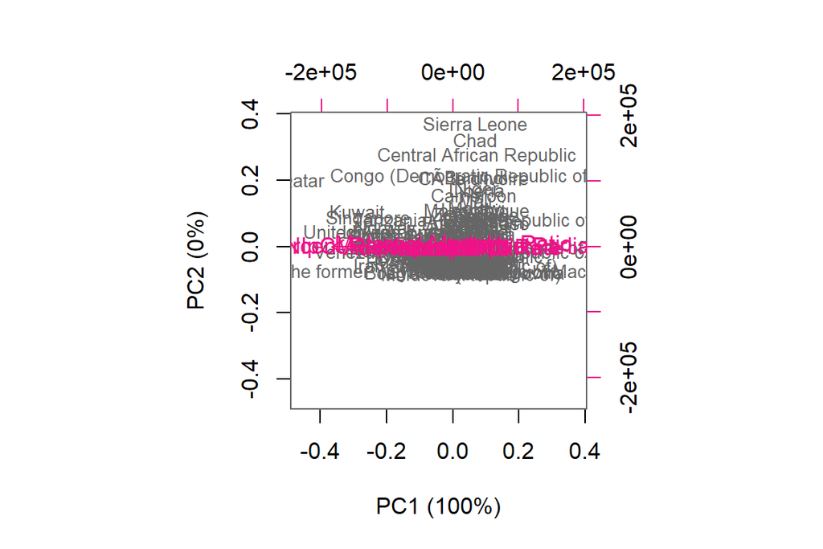

```r
pc_lab <- paste0(names(pca_pr), " (", pca_pr, "%)")
biplot(pca_human, cex = c(0.8, 1), col = c("grey40", "deeppink2"), xlab = pc_lab[1], ylab = pc_lab[2])
```

```r
#The graph seems to use GNI per capita as a reversed and the y-axis appears to be a mix of the other categories. I think it's having trouble misinterpreting numbers with for example high maternal mortality rate being bad but high education ratio being good, which is why the y-axis seems a little nonsensical.
human_std<-scale(human)
summary(human_std)
```

```
##      LifeE         eduyearsexpect        GNIpC
##  Min.   :-2.7188   Min.   :-2.7378   Min.   :-0.9193
##  1st Qu.:-0.6425   1st Qu.:-0.6782   1st Qu.:-0.7243
##  Median : 0.3056   Median : 0.1140   Median :-0.3013
##  Mean   : 0.0000   Mean   : 0.0000   Mean   : 0.0000
##  3rd Qu.: 0.6717   3rd Qu.: 0.7126   3rd Qu.: 0.3712
##  Max.   : 1.4218   Max.   : 2.4730   Max.   : 5.6890
##  Maternal.Mortality.Ratio Adolescent.Birth.Rate
##  Min.   :-0.6992          Min.   :-1.1325
##  1st Qu.:-0.6496          1st Qu.:-0.8394
##  Median :-0.4726          Median :-0.3298
##  Mean   : 0.0000          Mean   : 0.0000
##  3rd Qu.: 0.1932          3rd Qu.: 0.6030
##  Max.   : 4.4899          Max.   : 3.8344
##  Percent.Representation.in.Parliament   eduratioFM        labratioFM
##  Min.   :-1.8203                      Min.   :-2.8189   Min.   :-2.6247
##  1st Qu.:-0.7409                      1st Qu.:-0.5233   1st Qu.:-0.5484
##  Median :-0.1403                      Median : 0.3503   Median : 0.2316
##  Mean   : 0.0000                      Mean   : 0.0000   Mean   : 0.0000
##  3rd Qu.: 0.6127                      3rd Qu.: 0.5958   3rd Qu.: 0.7350
##  Max.   : 3.1850                      Max.   : 2.6646   Max.   : 1.6632
```

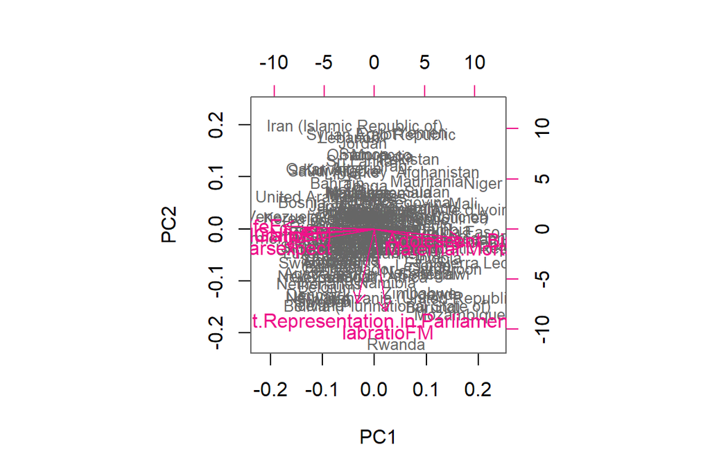

```r
pca_human2<-prcomp(human_std)
biplot(pca_human2, choices=1:2, cex=c(0.8, 1), col=c("grey40", "deeppink2"))
```

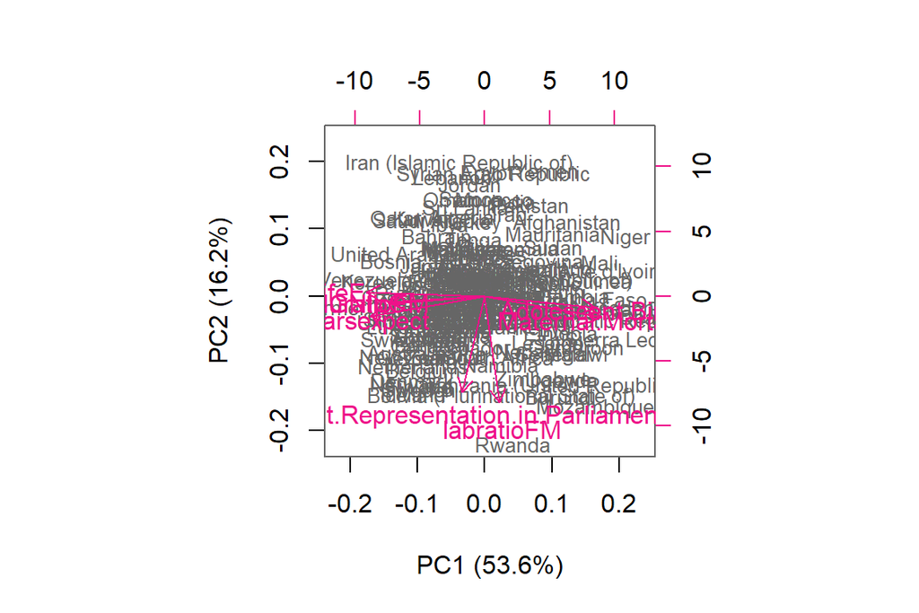

```r
s2<-summary(pca_human2)
pca_pr2 <- round(100*s2$importance[2, ], digits = 1)
pc_lab2 <- paste0(names(pca_pr2), " (", pca_pr2, "%)")
biplot(pca_human2, cex = c(0.8, 1), col = c("grey40", "deeppink2"), xlab = pc_lab2[1], ylab = pc_lab2[2])
```

*This result is much more interpretable and shows clear correlations between life expectancy, education and GNI, female representation in parliament and employment rate between genders and between adolescent birth rate and maternal mortality rate. The last group is almost directly opposite the first, meaning that they correlate inversely with each other, but the 2nd group is orthogonal to the other two, meaning that they have no correlation. Knowing this we can easily choose 2 principal components to represent the data.*

The results between the 2 graphs are different because it assumes that variables with larger variance are more important than those with small variance, so scaling the data is necessary to prevent a few categories from dominating the results.

Since life expectancy correlates strongly with education and gross national income and inversely with adolescent birth rates and maternal mortality ratios, we can use it as the first PC. Employment rate between genders and female representation in parliament don’t correlate all that strongly, but they’re both quite orthogonal to the other variables as well, so I’d choose one of them for the second PC

```r
library(FactoMineR)
data("tea")
str(tea)
```

```
## 'data.frame':    300 obs. of  36 variables:
##  $ breakfast       : Factor w/ 2 levels "breakfast","Not.breakfast": 1 1 2 2 1 2 1 2 1 1 ...
##  $ tea.time        : Factor w/ 2 levels "Not.tea time",..: 1 1 2 1 1 1 2 2 2 1 ...
##  $ evening         : Factor w/ 2 levels "evening","Not.evening": 2 2 1 2 1 2 2 1 2 1 ...
##  $ lunch           : Factor w/ 2 levels "lunch","Not.lunch": 2 2 2 2 2 2 2 2 2 2 ...
##  $ dinner          : Factor w/ 2 levels "dinner","Not.dinner": 2 2 1 1 2 1 2 2 2 2 ...
##  $ always          : Factor w/ 2 levels "always","Not.always": 2 2 2 2 1 2 2 2 2 2 ...
##  $ home            : Factor w/ 2 levels "home","Not.home": 1 1 1 1 1 1 1 1 1 1 ...
##  $ work            : Factor w/ 2 levels "Not.work","work": 1 1 2 1 1 1 1 1 1 1 ...
##  $ tearoom         : Factor w/ 2 levels "Not.tearoom",..: 1 1 1 1 1 1 1 1 1 2 ...
##  $ friends         : Factor w/ 2 levels "friends","Not.friends": 2 2 1 2 2 2 1 2 2 2 ...
##  $ resto           : Factor w/ 2 levels "Not.resto","resto": 1 1 2 1 1 1 1 1 1 1 ...
##  $ pub             : Factor w/ 2 levels "Not.pub","pub": 1 1 1 1 1 1 1 1 1 1 ...
##  $ Tea             : Factor w/ 3 levels "black","Earl Grey",..: 1 1 2 2 2 2 2 1 2 1 ...
##  $ How             : Factor w/ 4 levels "alone","lemon",..: 1 3 1 1 1 1 1 3 3 1 ...
```

[output cut: 22 more lines]

```r
dim(tea)
```

```
## [1] 300  36
```

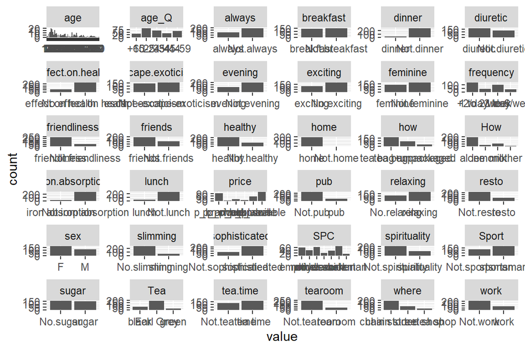

```r
gather(tea)%>%ggplot(aes(value))+facet_wrap("key", scales="free") + geom_bar()
```

```r
keep_columns <- c("Tea", "How", "how", "sugar", "where", "lunch")
tea_time <- dplyr::select(tea, one_of(keep_columns))
mca <- MCA(tea_time, graph = F)
summary(mca)
```

```
##
## Call:
## MCA(X = tea_time, graph = F)
##
##
## Eigenvalues
##                        Dim.1   Dim.2   Dim.3   Dim.4   Dim.5   Dim.6
## Variance               0.279   0.261   0.219   0.189   0.177   0.156
## % of var.             15.238  14.232  11.964  10.333   9.667   8.519
## Cumulative % of var.  15.238  29.471  41.435  51.768  61.434  69.953
##                        Dim.7   Dim.8   Dim.9  Dim.10  Dim.11
## Variance               0.144   0.141   0.117   0.087   0.062
## % of var.              7.841   7.705   6.392   4.724   3.385
## Cumulative % of var.  77.794  85.500  91.891  96.615 100.000
##
## Individuals (the 10 first)
##                       Dim.1    ctr   cos2    Dim.2    ctr   cos2    Dim.3
## 1                  | -0.298  0.106  0.086 | -0.328  0.137  0.105 | -0.327
## 2                  | -0.237  0.067  0.036 | -0.136  0.024  0.012 | -0.695
## 3                  | -0.369  0.162  0.231 | -0.300  0.115  0.153 | -0.202
## 4                  | -0.530  0.335  0.460 | -0.318  0.129  0.166 |  0.211
## 5                  | -0.369  0.162  0.231 | -0.300  0.115  0.153 | -0.202
## 6                  | -0.369  0.162  0.231 | -0.300  0.115  0.153 | -0.202
## 7                  | -0.369  0.162  0.231 | -0.300  0.115  0.153 | -0.202
## 8                  | -0.237  0.067  0.036 | -0.136  0.024  0.012 | -0.695
## 9                  |  0.143  0.024  0.012 |  0.871  0.969  0.435 | -0.067
## 10                 |  0.476  0.271  0.140 |  0.687  0.604  0.291 | -0.650
##                       ctr   cos2
## 1                   0.163  0.104 |
## 2                   0.735  0.314 |
## 3                   0.062  0.069 |
## 4                   0.068  0.073 |
## 5                   0.062  0.069 |
## 6                   0.062  0.069 |
## 7                   0.062  0.069 |
## 8                   0.735  0.314 |
## 9                   0.007  0.003 |
## 10                  0.643  0.261 |
##
## Categories (the 10 first)
```

[output cut: 16 more lines]

```
## lemon                0.035   3.226 |   1.329  14.771   0.218   8.081 |
## milk                 0.020   2.422 |   0.013   0.003   0.000   0.116 |
## other                0.102   5.534 |  -2.524  14.526   0.197  -7.676 |
## tea bag              0.161  -6.941 |  -0.065   0.183   0.006  -1.287 |
## tea bag+unpackaged   0.478  11.956 |   0.019   0.009   0.000   0.226 |
## unpackaged           0.141  -6.482 |   0.257   0.602   0.009   1.640 |
##
## Categorical variables (eta2)
##                      Dim.1 Dim.2 Dim.3
## Tea                | 0.126 0.108 0.410 |
## How                | 0.076 0.190 0.394 |
## how                | 0.708 0.522 0.010 |
## sugar              | 0.065 0.001 0.336 |
## where              | 0.702 0.681 0.055 |
## lunch              | 0.000 0.064 0.111 |
```

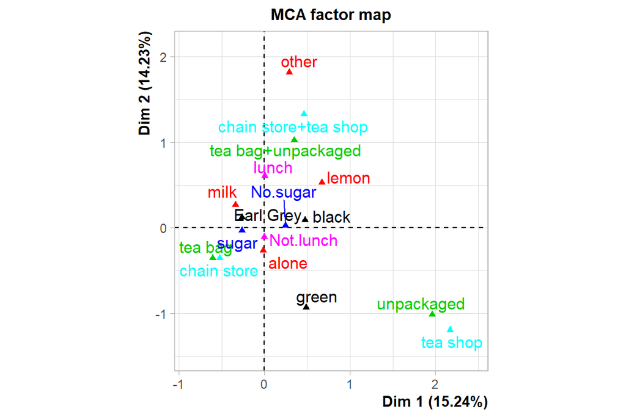

```r
plot(mca, invisible=c("ind"), habillage="quali")
```

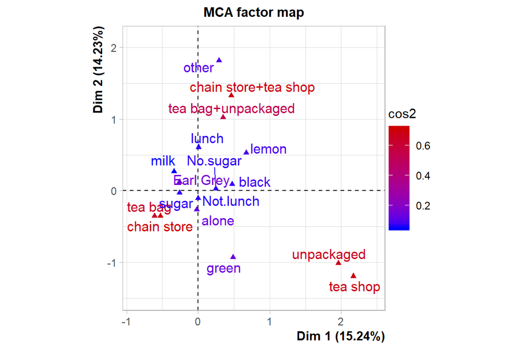

```r
plot(mca, invisible=c("ind"), habillage="cos2")
```

*From the graph we can see that tea shops often serve their tea unpackaged, while chain stores tend to use tea bags, and tea shop+chain store combinations do both. Green tea drinkers don’t seem to have any other constant preferences, since green tea is not near any other variables. A lot of the most common variables such as sugar, no sugar, earl grey and not lunch are near each other, showing that they tend to appeal to the average user in a similar way. The ‘other’ category is also very lonely, meaning that drinkers of that kind are quite unusual compared to the average tea enthusiasts, though the sample size might be too low to say anything definitive.*